# VOTER Survey - Part 2

Kate Ham 2020-02-18

- 2016 vote by social and economic views
- Estimated size of groups
- How groups’ vote changed between 2012 and 2016

```r
# Libraries
library(tidyverse)
library(dcl)
library(knitr)

# Parameters
  # File with VOTER Survey data
file_voter_survey <- "../../data/voter-survey/data.rds"
  # File for answers
file_answers <- "../../data/voter-survey/answers_2.rds"

#===============================================================================

# Read in answers
answers <- read_rds(file_answers)
```

The [Democracy Fund Voter Study Group](https://www.voterstudygroup.org) “is a research collaboration comprised of nearly two dozen analysts and scholars from across the political spectrum offering new data and analysis exploring American voter’s beliefs and behaviors.” They commissioned the Views of the Electorate Research Survey (VOTER Survey) after the 2016 U.S. presidential election. This was a survey of 8,000 voting-age adults on how they voted in both the 2012 and 2016 presidential elections together with the answers to over 600 other questions. Researchers are using the data from this survey to seek insights into the electorate and the 2016 election.

In Part 1, you derived variables on the views of those surveyed on issues that were salient during the campaign. The result is in the file `file_voter_survey`. In this part, you will visualize this data to seek to understand the relationship of these views to how voters voted in the 2016 election and how their votes changed between 2012 and 2016.

## 2016 vote by social and economic views

Two of the derived variables were composites

- `social`: Combination of views on moral issues, and views towards African-Americans, immigrants, and Muslims
- `economic`: Combination of views on social safety net, trade, inequality, and the role of government

**q1** Create a presentation plot of `social` vs. `economic` together with how each voter voted in the 2016 election. Why is this plot misleading? Nevertheless, what insights does it provide, especially for the Democrats?

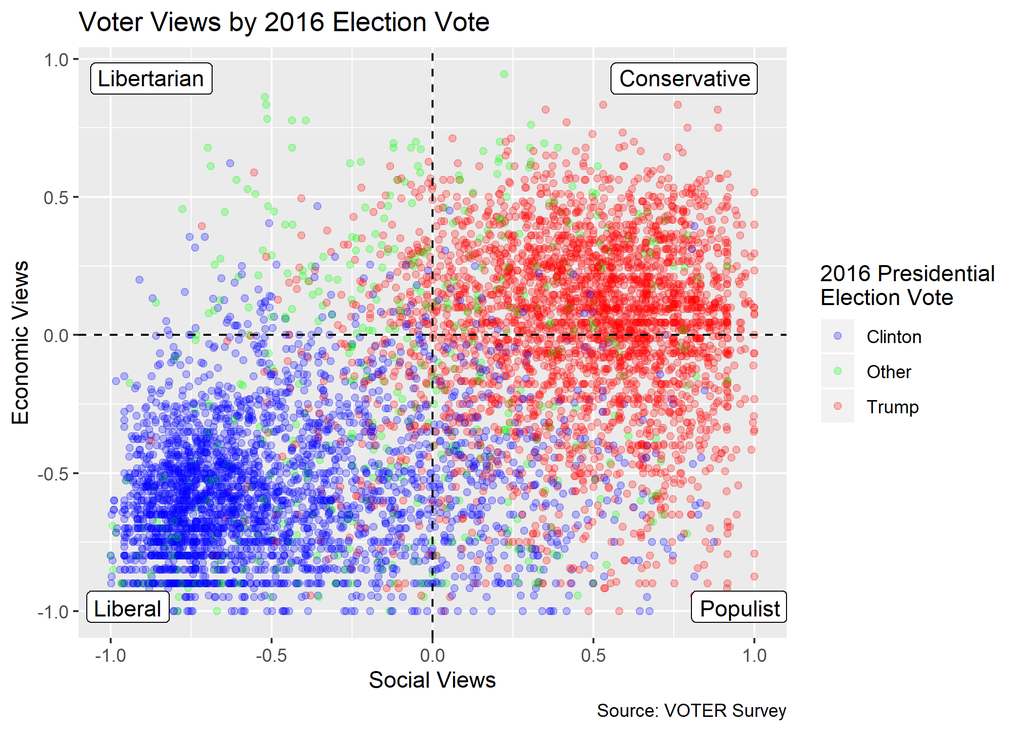

```r
voter_survey <- read_rds(file_voter_survey)

voter_survey %>%
  drop_na() %>%
  ggplot(aes(social, economic, color = vote_2016)) +
  geom_point(alpha = 0.25) +
  geom_hline(yintercept = 0, linetype = "dashed") +
  geom_vline(xintercept = 0, linetype = "dashed") +
  scale_color_manual(values = c("blue", "green", "red")) +
  annotate(
    geom = "label",
    x = c(-Inf, Inf, Inf, -Inf),
    y = c(Inf, Inf, -Inf, -Inf),
    label = c("Libertarian", "Conservative", "Populist", "Liberal"),
    hjust = c(-0.1, 1.2, 1, -0.1),
    vjust = c(1.5, 1.5, -0.5, -0.5)
  ) +
  labs(
    title = "Voter Views by 2016 Election Vote",
    color = "2016 Presidential \nElection Vote",
    caption = "Source: VOTER Survey",
    x = "Social Views",
    y = "Economic Views"
  )
```

This plot is misleading because each case is weighted by the US population that it represents, according to the study; for example cases with less weight are overrepresented in this plot.

Nonetheless, we observe that Clinton voters are socially and fiscally liberal whereas Trump voters are socially and fiscally conservative. More importantly, note that there are significant portions of Democrats and Republicans that are populists. The Democrats, with Clinton as the nominee, did not appeal to the socially conservative but economically liberal voter base.

## Estimated size of groups

**q2.1** Each row of the dataset contains the data for a single individual who was polled. From the individual’s demographic information and the prevalence of these demographic characteristics in the sampled population, pollsters can assign individuals weights. These weights can then be used to adjust polls for non-representative sampling. For example, suppose a poll consisted 40% women and 60% men. If the pollster knows that the sampled population actually consists of 50% women and 50% men, then they can give the women a weight of 5 / 4 and the men a weight of 5 / 6. The weights are then used to make weighted averages of poll responses.

The proportion of the popular vote in the 2016 presidential election was

| vote_2016 | prop |
| --- | --- |
| Clinton | 0.482 |
| Trump | 0.461 |
| Other | 0.057 |

Calculate the proportion of the vote for the candidates in the VOTER Survey. How close are the results to the actual vote? Be sure to use `weight`.

```r
q2.1 <-
  voter_survey %>%
  count(vote_2016, wt = weight) %>%
  drop_na() %>%
  mutate(
    prop = n/sum(n)
  ) %>%
  select(-n)

# Print results
if (exists("q2.1")) q2.1 %>% arrange(desc(prop)) %>% kable(digits = 3)
```

| vote_2016 | prop |
| --- | --- |
| Clinton | 0.471 |
| Trump | 0.462 |
| Other | 0.067 |

```r
# Compare result with answer
if (exists("q2.1")) compare(answers$q2.1, q2.1)
```

```
## TRUE
```

**q2.2** Now compute and visualize the size of each of the groups in `group` by proportion. What conclusions can you draw?

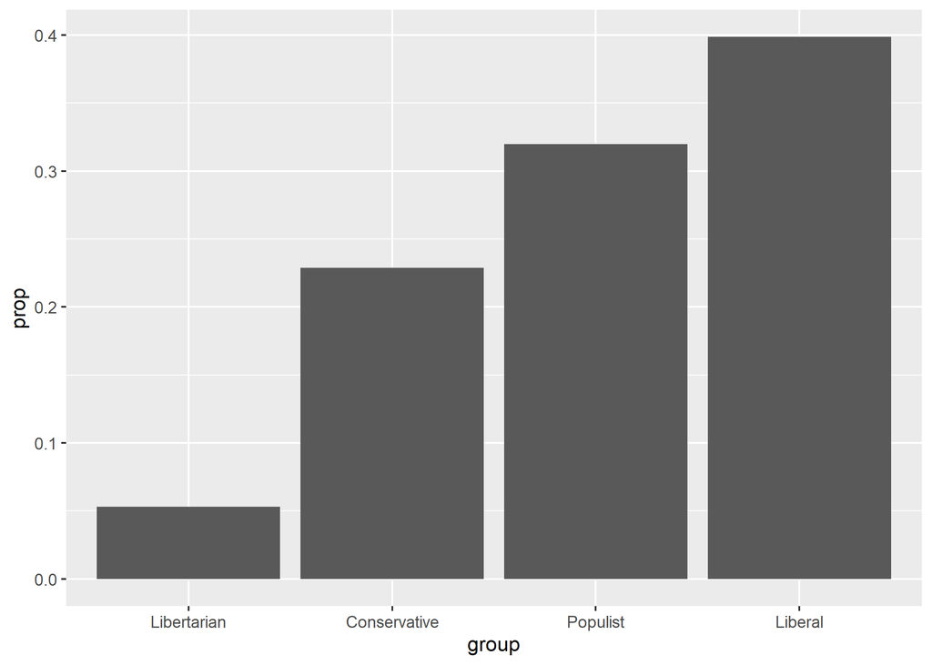

```r
q2.2 <-
  voter_survey %>%
  count(group, wt = weight) %>%
  drop_na() %>%
  mutate(
    prop =  n/sum(n)
  ) %>%
  select(-n)

q2.2 %>%
  mutate(group = fct_reorder(group, prop)) %>%
  ggplot(aes(group, prop)) +
  geom_col()
```

```r
# Print results
if (exists("q2.2")) q2.2 %>% arrange(desc(prop)) %>% kable(digits = 3)
```

| group | prop |
| --- | --- |
| Liberal | 0.399 |
| Populist | 0.320 |
| Conservative | 0.229 |
| Libertarian | 0.053 |

```r
# Compare result with answer
if (exists("q2.2")) compare(answers$q2.2, q2.2)
```

```
## TRUE
```

There were very few libertarians, and in fact while one might suspect conservatives and liberals to be the highest proportion since they are rooted in the Republican and Democratic parties respectively, a significant portion of 2016 voters are populists.

## How groups’ vote changed between 2012 and 2016

**q3.1** For each of the four groups in `group` calculate the proportion of the group that voted for the Democratic candidate, the Republican candidate, and Other candidates for both 2012 and 2016.

```r
q3.1 <-
  voter_survey %>%
  drop_na(group, vote_2012, vote_2016) %>%
  pivot_longer(
    cols = c(vote_2012, vote_2016),
    names_sep = "_",
    names_to = c("vote","year"),
    values_to = "party"
  ) %>%
  transmute(
    case_identifier,
    weight,
    group,
    year = as.integer(year),
    party =
      case_when(
        party %in% c("Obama", "Clinton") ~ "Democrat",
        party %in% c("Romney", "Trump") ~ "Republican",
        TRUE ~ "Other"
      )
  ) %>%
  count(group, year, party, wt = weight) %>%
  group_by(year, group) %>%
  mutate(
    prop = n/sum(n)
  ) %>%
  select(-n) %>%
  ungroup()

# Compare result with answer
if (exists("q3.1")) compare(answers$q3.1, q3.1)
```

```
## TRUE
```

**q3.2** For each group and each election, there were proportions of votes cast for Democrat, Republican, and Other. Using `q3.1`, create a presentation plot that shows for each group how these proportions changed between 2012 and 2016. What conclusions can you draw?

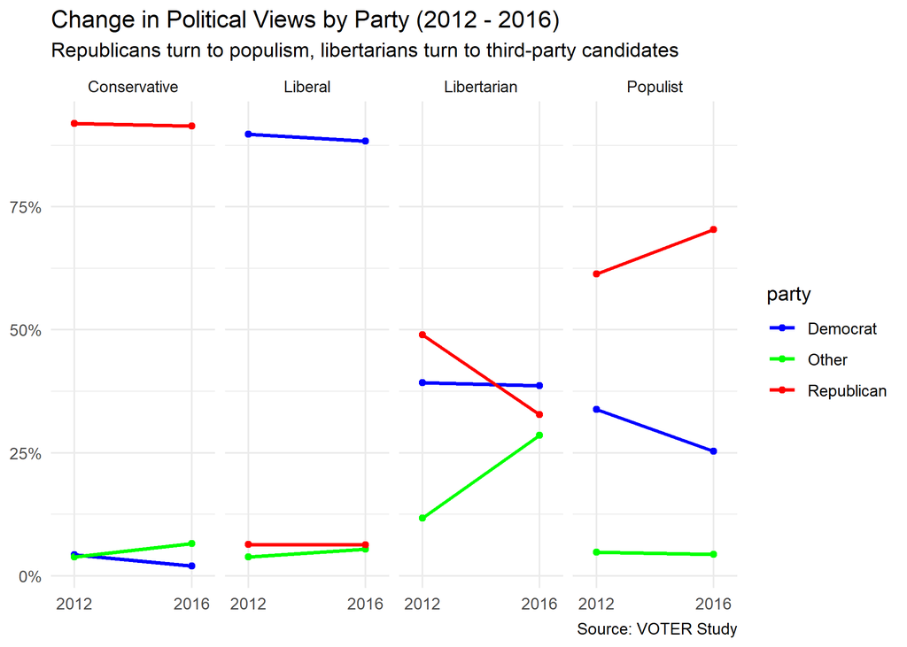

```r
q3.1 %>%
  ggplot(aes(factor(year), prop, color = party, group = party)) +
  geom_point() +
  geom_line(size = 1) +
  facet_wrap(~ group, nrow = 1) +
  scale_color_manual(values = c("blue", "green", "red")) +
  scale_x_discrete(expand = c(0.1, 0.1)) +
  scale_y_continuous(label = scales::label_percent(accuracy = 1)) +
  theme_minimal() +
  labs(
    title = "Change in Political Views by Party (2012 - 2016)",
    subtitle = "Republicans turn to populism, libertarians turn to third-party candidates",
    caption = "Source: VOTER Study",
    x = NULL,
    y = NULL
  )
```

After you finish this task, please complete [Notes on Task - Part 1](https://forms.gle/NdSN5Tye6EtMiXAm8).